# Análisis Estadístico con R

Víctor Morales-Oñate

[Sitio Personal](https://sites.google.com/site/moralesonatevictor/), [LinkedIn](https://www.linkedin.com/in/vmoralesonate/), [ResearchGate](https://www.researchgate.net/profile/Victor_Morales-Onate)

12 de abril de 2021

# Procedimientos Gráficos

- Una de las grandes potencialidades en R es la calidad gráfica. Su potencialidad es del mismo nivel e incluso superior al de muchos software comerciales.
- Resultaría un curso exclusivo de graficación en R para poder dar a conocer todas las posibilidades de graficación en la herramienta. Para ilustrar algunas posibilidades:

```r
demo(graphics)
```

## Funciones Gráficas

- El resultado de una función gráfica no puede ser asignado a un objeto sino que es enviado a un dispositivo gráfico. Un dispositivo gráfico es una ventana gráfica o un archivo.
- Existen dos tipos de funciones gráficas: + Funciones de *gráficas de alto nivel*: Crean una nueva gráfica + Funciones de *gráficas de bajo nive*l: agregan elementos a una gráfica existente
- Las gráficas se producen con respecto a *parámetros gráficos* que están definidos por defecto y pueden ser modificados con la función `par`.

### Funciones gráficas de alto nivel

| Función | Descripción |
| --- | --- |
| `plot(x)` | graficar los valores de x (en el eje y) ordenados en el eje x |
| `plot(x,y)` | gráfico bivariado de x (en el eje x) y y (en el eje y) |
| `pie(x)` | gráfico circular tipo *pie* |
| `boxplot(x)` | Gráfico de caja y bigotes |
| `hist(x)` | histograma de las frecuencias de x |
| `barplot(x)` | histograma de los valores de x |

- Las opciones de cada unas de las funciones se pueden ver en la ayuda de R.
- Las principales son:

| Opción | Descripción |
| --- | --- |
| `add=FALSE` | si es TRUE superpone el gráfico en el ya existente (si existe) |
| `axes=TRUE` | si es FALSE no dibuja los ejes ni la caja del gráfico |
| `type="p"` | especifica el tipo de gráfico; `"p"`: puntos, `"l"`: líneas, `"h"`: líneas verticales, `"s"`: escaleras, los datos se representan como la parte superior de las líneas verticales, entre otros |
| `xlim=`, `ylim=` | especifica los límites inferiores y superiores de los ejes; por ejemplo con `xlim=c(1, 10)` o `xlim=range(x)` |
| `main=` | Título principal; debe ser de tipo caracter |
| `sub=` | sub-título (escrito en una letra más pequeña) |

#### La función `plot(x)`

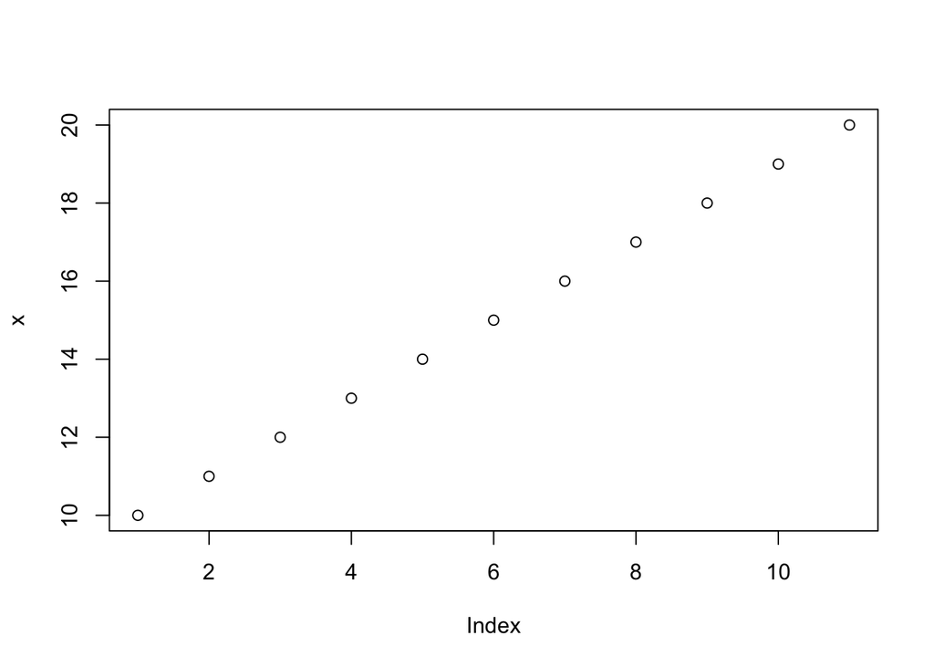

```r
x <- seq(10,20,1)
plot(x)
```

#### La función `plot(x,y)`

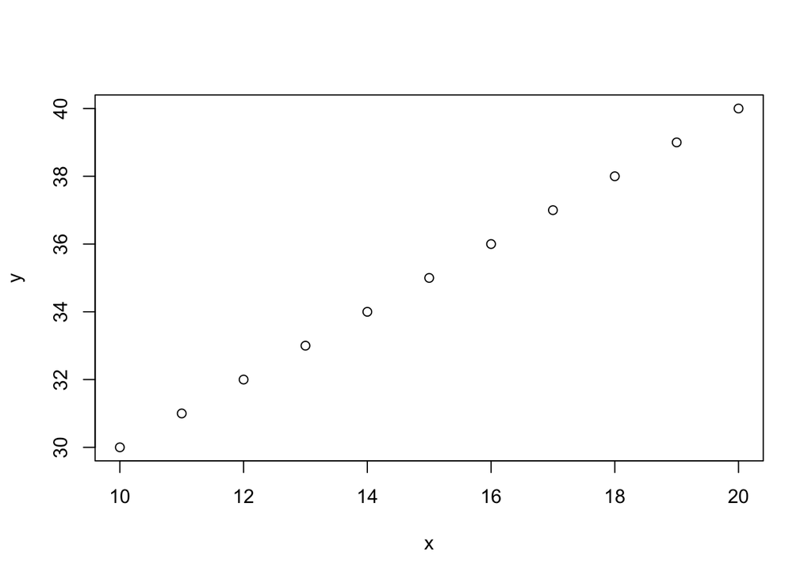

```r
y <- seq(30,40,1)
plot(x,y)
```

#### Boxplot

- También se le llama gráfico de caja y bigotes, refleja gráficamente el resumen de estadísticas principales (Min,Q1,Mediana,Q3,Max, Outlayers). Importa los datos `Mundo.csv` y…

```r
boxplot(PNB_PC)
boxplot(log(PNB_PC))
```

- Exácto! Es muy probable que hayas obtenido un error (**¿Por qué?**). Hay dos formas de solucionarlo. Una de las formas sería:

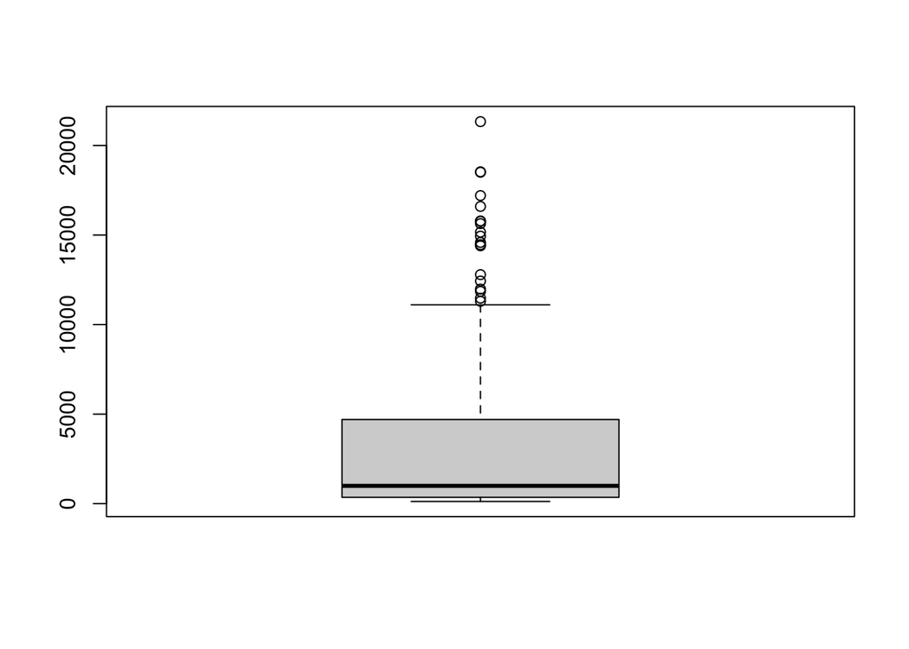

```r
boxplot(datos$PNB_PC)
```

- Mmmm, algo anda mal, la variable no se puede apreciar muy bien. Tratemos visualizarla haciendo una transformación logarítmica:

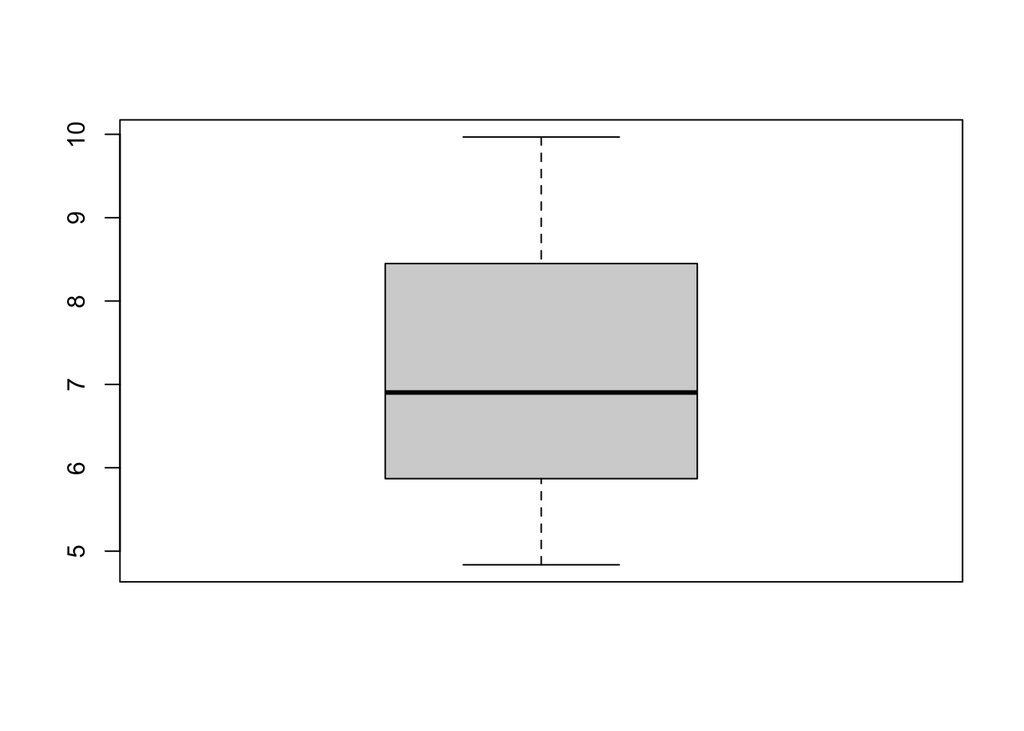

```r
boxplot(log(datos$PNB_PC))
```

En general, si al aplicar el boxplot sobre una variable se tiene problemas para visualizarla, se debe usar el lograritmo de la variable para una mejor lectura de la variable.

- Otra forma de solucionar el problema anterior es usando el comando `attach`. Esta función es utilizada para poder *ingresar* a las variables de un `data frame` sin el operador `$`. Así

```r
attach(datos)
```

- Realicemos varios `boxplot` a la vez.

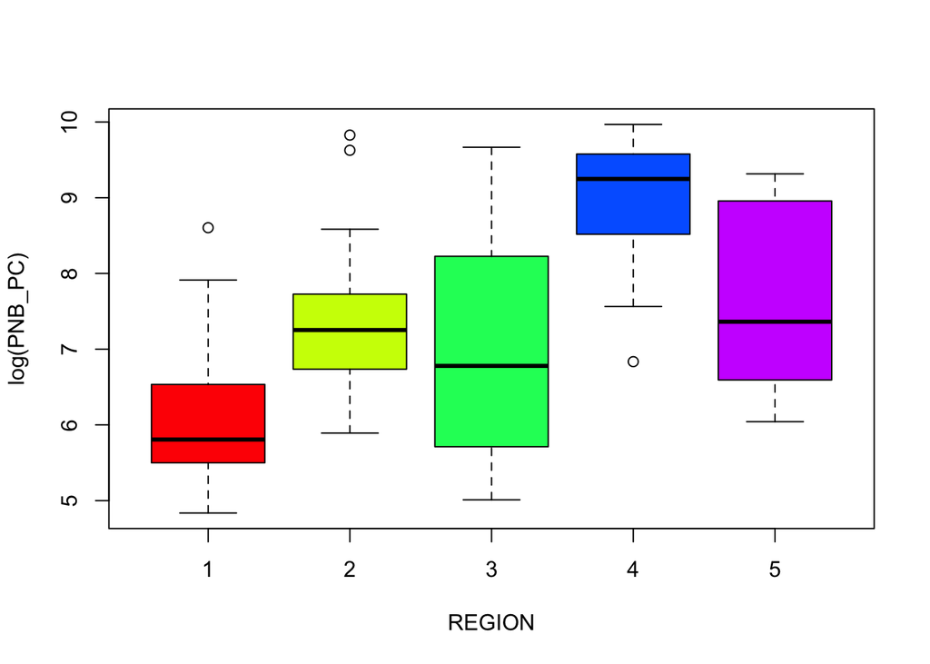

```r
boxplot(log(PNB_PC)~REGION, col=rainbow(5),data = datos)
```

- Agreguemos etiquetas:

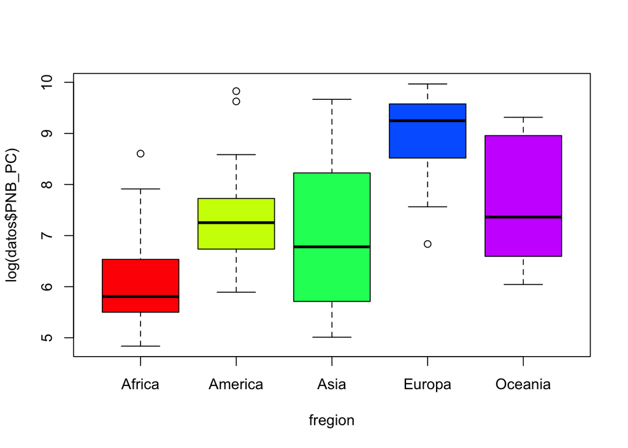

```r
fregion <- factor(datos$REGION,labels=c("Africa","America","Asia","Europa","Oceania"))
boxplot(log(datos$PNB_PC)~fregion, col=rainbow(5))
```

#### Pie

- Realiza un gráfico de *PIE* de los datos (tiene sentido cuando son datos de suma 100)

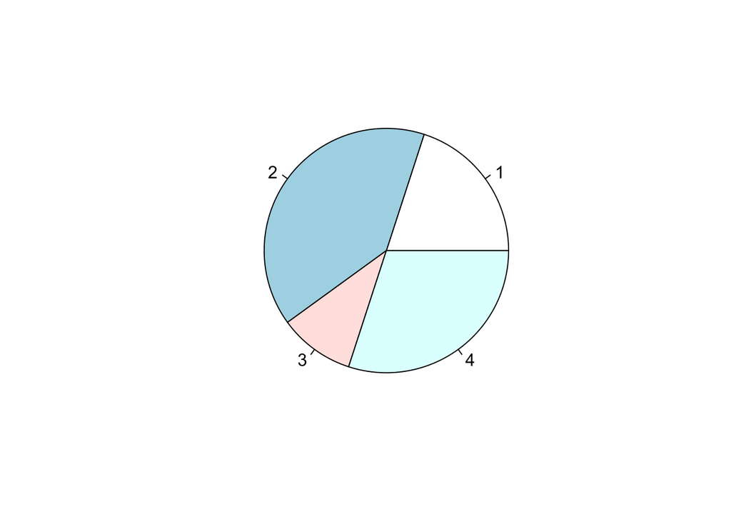

```r
z.pie <- c(20,40,10,30)
pie(z.pie)
```

- Con etiquetas

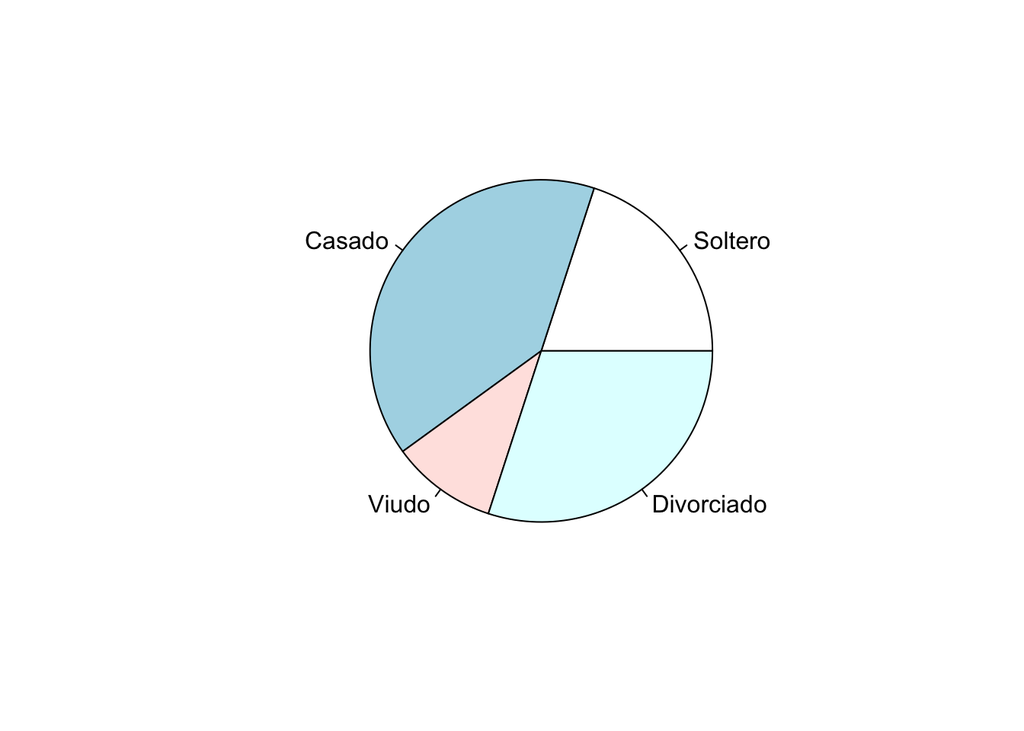

```r
names(z.pie) <- c("Soltero", "Casado","Viudo",  "Divorciado")
pie(z.pie)
```

- Con colores elegidos (más opciones de colores puedes encontrarlos [aquí](http://www.stat.columbia.edu/~tzheng/files/Rcolor.pdf))

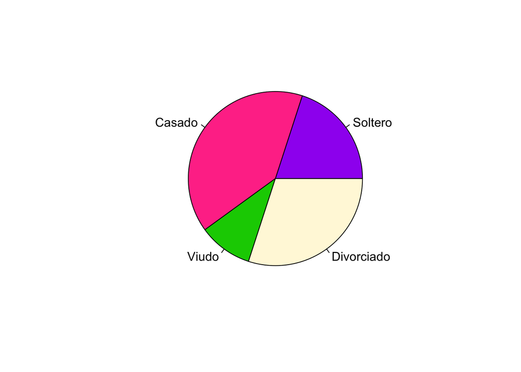

```r
pie(z.pie, col = c("purple", "violetred1",  "green3","cornsilk"))
```

- Juguemos un poco con las opciones: + Realizar un `plot` de $x$ e $y$ (ya creados) con las siguientes opciones: + Título: Gráficas en R + Subtítulo: Centro de Estudios Fiscales + Etiquetas en ejes: `"Eje X"`, `"Eje Y"` Respectivamente + Gráfico tipo escalera + Color Azul

### Funciones gráficas de bajo nivel

| Función | Descripción |
| --- | --- |
| `points(x, y)` | Agrega puntos |
| `lines(x,y)` | Mismo que points pero con líneas |
| `segments(x0, y0, x1, y1)` | dibuja una línea desde el punto ($x_0$,$y_0$) hasta el punto ($x_1$,$y_1$) |
| `abline(a,b)` | dibuja una línea con pendiente b e intercepto a |

#### Curve

Sirve para graficar funciones, el formato es

> `curve(expr, from, to, add=FALSE,...)`

Por ejemplo:

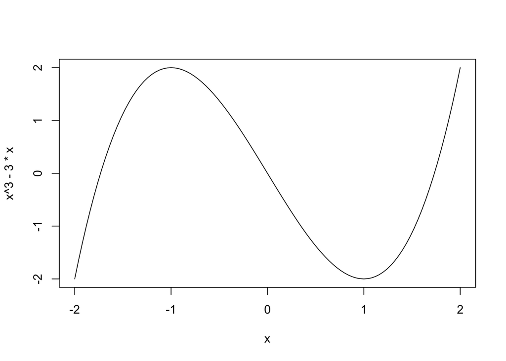

```r
curve(x^3-3*x,-2,2)
```

**Micro práctica**

- Realiza una gráfica del conjunto de datos `women` (`women` es una base de datos *precargada* en `R`, se accede a ella con `data(women)`). Coloque `"Altura"` como etiqueta en el eje x y `"Peso"` en el $y$. Como título ponga `"Valores promedio de altura y peso"`, subtitulo: "`Mujeres de 30 a 39 años"`. El gráfico debe lucir así:

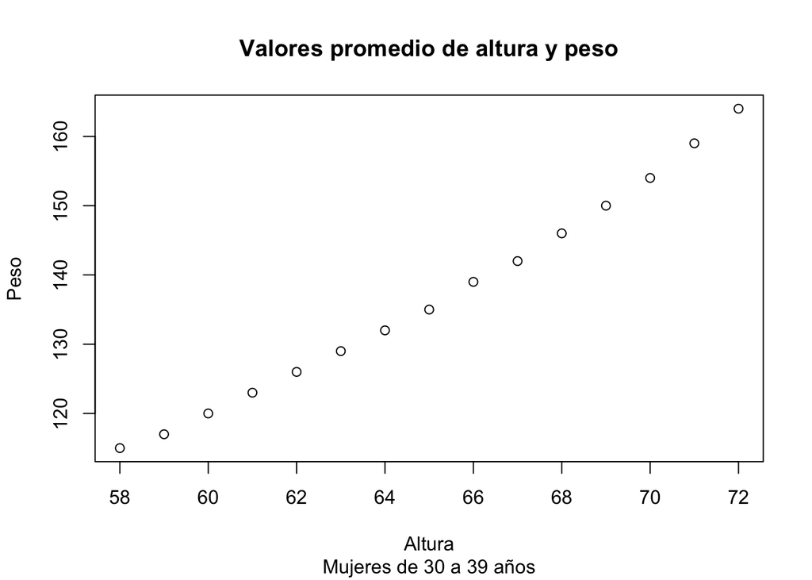

- Haga una gráfica de la función $cos(3x)$ de $0$ a $3$, de color azul. Superponga la gráfica de $sin(2x)$ de color rojo. La gráfica debe lucir así:

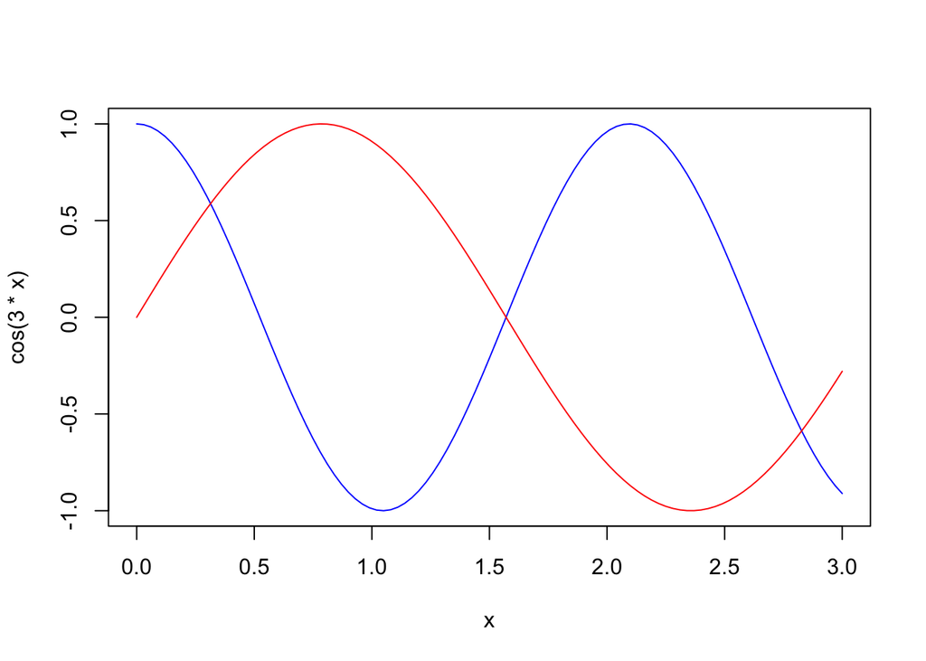

- Cerremos esta primera parte gráfica con un ejemplo en 3D:

```r
library(rgl)
r <- 1
a <- runif(1000,0,2*pi)
u <- runif(1000,-r,r)

x <- cos(a)*sqrt(1-u^2)
y <- sin(a)*sqrt(1-u^2)
z <- u
plot3d(x,y,z,col="blue")
```

- Hasta el momento hemos cubierto formas básicas de hacer gráficos. Existen opciones más avanzas como lattice, ggplot2 y ggvis. Hagamos un breve paseo por `ggplot` y luego hacemos una práctica:

#### `ggplot2`

Un gráfico básico (usando lo aprendido hasta ahora)

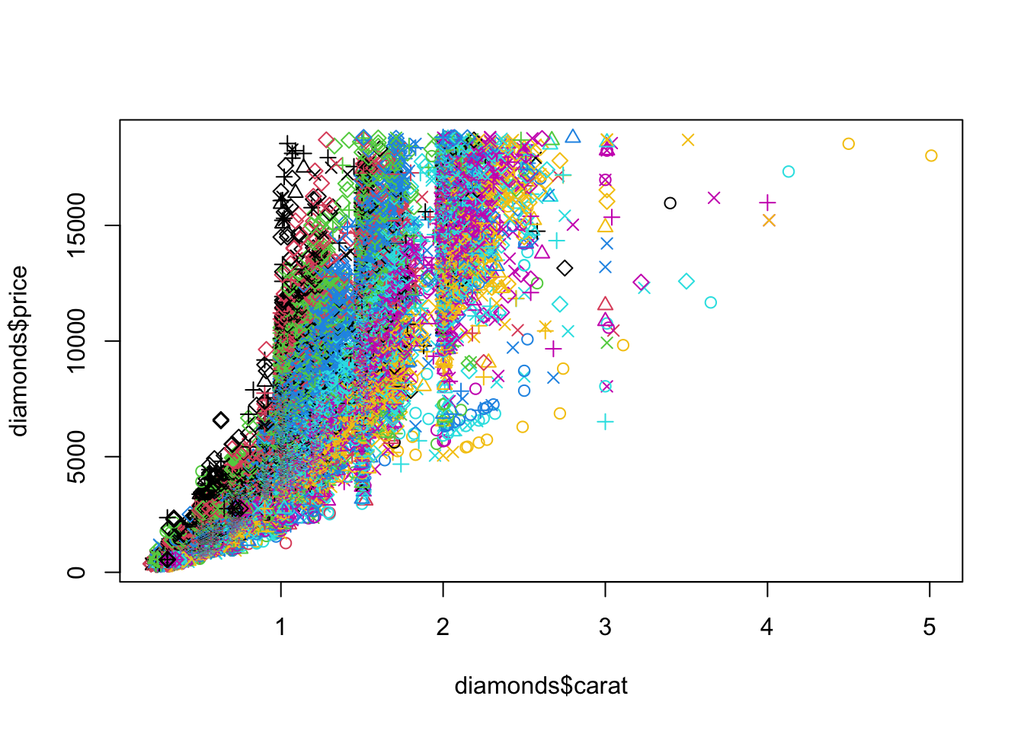

```r
# Obtenemos los datos
library(ggplot2)
data(diamonds)

# basic plotting
plot(diamonds$carat, diamonds$price, col = diamonds$color,
    pch = as.numeric(diamonds$cut))
```

Usando `ggplot`:

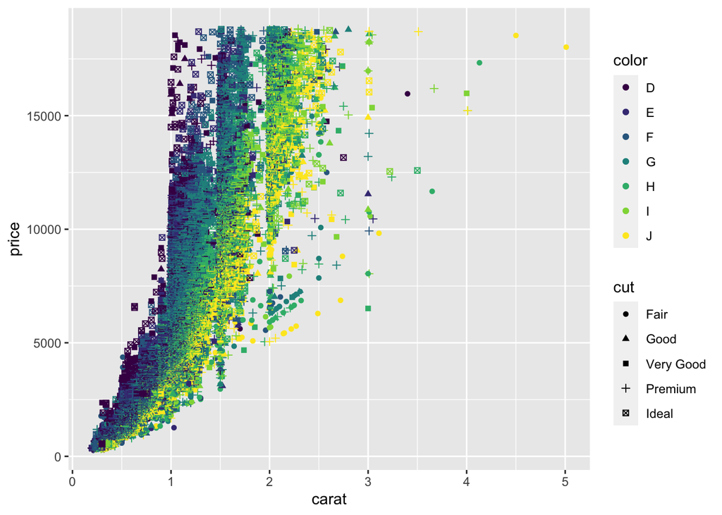

```r
ggplot(diamonds, aes(carat, price, col = color, shape = cut)) +
    geom_point()
```

# Práctica

- Abra los datos de R `cars`. Es una buena práctica el conocer los nuestros datos. Mira la ayuda de `cars`.
- Ejecuta `head(cars)`. Para tener una mejor idea de nuestros datos, podemos usar funciones como: `dim()`, `names()`, `head()`, `tail()` y `summary()`.
- Hagamos un gráfico básico `plot(cars)` + `R` nota que el data frame tiene sólo dos columnas, por lo que asume que deseas graficar una columna vs la otra.
- Además, ya que no se proporcionan etiquetas para los ejes, `R` utiliza los nombres de las columnas.
- Ahora, ejecuta `plot(x = cars$speed, y = cars$dist)`. ¿Notas alguna diferencia con el gráfico anterior?
- Ten en cuenta que hay otras maneras de usar el comando `plot`, esto es, utilizando el interfaz de `"fórmula"`. Por ejemplo, tenemos gráfico similar al anterior con `plot(dist ~ speed, cars)`. Sin embargo, vamos a usar más tarde en la práctica antes de utilizar la interfaz de fórmula.
- Hagamos un gráfico de cars con `dist` en el eje $x$ y `speed` en el eje $y$.
- En el gráfico anterior, agrega la etiqueta `"Speed"` en el eje $x$.
- En el gráfico anterior, agrega la etiqueta `"Stopping Distance"` en el eje $y$.
- Ahora, agrega el título `"My Plot"`.
- Agrega el subtítulo `"My Plot Subtitle"`.
- Agrega la opción `col=2`
- Limita los ejes usando la opción `xlim = c(10,15)`
- Podemos cambiar la forma de los puntos, trata con la opción `pch = 2`.
- Carga los datos `mtcars`. Usa `boxplot()` con la fórmula = `mpg ~ cyl` y `data = mtcars`.
- Finalmente, realiza un histograma de `mtcars$mpg` con la función `hist`.